# Fordgobike trip data Analysis

## by Yusuf Ahmed Yusuf

### Briefly introduce your dataset here

> This dataset about bike share system in Fransicsco, California. At first let me introduse what is the meaning of bike share system, the bikes designed specially for the system, the users take the bike from the station and ride it to their destination and then dock it in any location in the city, so users unlock bikes from any station and returned it to another. The bike share system make the riding and moving in the city easily.

> All data In 2019, Feburary. The data provides info about the trips and stations that used in the system, also provides data about users like their type (Customer or Subscriber), members gender and the duratiuon time of trips.

## Preliminary Wrangling

```python
# import all packages and set plots to be embedded inline
import numpy as np
import pandas as pd
import matplotlib.pyplot as plt
import seaborn as sb

%matplotlib inline
```

> Load in your dataset and describe its properties through the questions below. Try and motivate your exploration goals through this section.

```python
df = pd.read_csv('201902-fordgobike-tripdata.csv')
df.head()
```

|  | duration_sec | start_time | end_time | start_station_id | start_station_name | start_station_latitude | start_station_longitude | end_station_id | end_station_name | end_station_latitude | end_station_longitude | bike_id | user_type | member_birth_year | member_gender | bike_share_for_all_trip |
| --- | --- | --- | --- | --- | --- | --- | --- | --- | --- | --- | --- | --- | --- | --- | --- | --- |
| 0 | 52185 | 2019-02-28 17:32:10.1450 | 2019-03-01 08:01:55.9750 | 21.0 | Montgomery St BART Station (Market St at 2nd St) | 37.789625 | -122.400811 | 13.0 | Commercial St at Montgomery St | 37.794231 | -122.402923 | 4902 | Customer | 1984.0 | Male | No |
| 1 | 42521 | 2019-02-28 18:53:21.7890 | 2019-03-01 06:42:03.0560 | 23.0 | The Embarcadero at Steuart St | 37.791464 | -122.391034 | 81.0 | Berry St at 4th St | 37.775880 | -122.393170 | 2535 | Customer | NaN | NaN | No |
| 2 | 61854 | 2019-02-28 12:13:13.2180 | 2019-03-01 05:24:08.1460 | 86.0 | Market St at Dolores St | 37.769305 | -122.426826 | 3.0 | Powell St BART Station (Market St at 4th St) | 37.786375 | -122.404904 | 5905 | Customer | 1972.0 | Male | No |
| 3 | 36490 | 2019-02-28 17:54:26.0100 | 2019-03-01 04:02:36.8420 | 375.0 | Grove St at Masonic Ave | 37.774836 | -122.446546 | 70.0 | Central Ave at Fell St | 37.773311 | -122.444293 | 6638 | Subscriber | 1989.0 | Other | No |
| 4 | 1585 | 2019-02-28 23:54:18.5490 | 2019-03-01 00:20:44.0740 | 7.0 | Frank H Ogawa Plaza | 37.804562 | -122.271738 | 222.0 | 10th Ave at E 15th St | 37.792714 | -122.248780 | 4898 | Subscriber | 1974.0 | Male | Yes |

```python
df.shape
```

```
(183412, 16)
```

```python
df.describe()
```

|  | duration_sec | start_station_id | start_station_latitude | start_station_longitude | end_station_id | end_station_latitude | end_station_longitude | bike_id | member_birth_year |
| --- | --- | --- | --- | --- | --- | --- | --- | --- | --- |
| count | 183412.000000 | 183215.000000 | 183412.000000 | 183412.000000 | 183215.000000 | 183412.000000 | 183412.000000 | 183412.000000 | 175147.000000 |
| mean | 726.078435 | 138.590427 | 37.771223 | -122.352664 | 136.249123 | 37.771427 | -122.352250 | 4472.906375 | 1984.806437 |
| std | 1794.389780 | 111.778864 | 0.099581 | 0.117097 | 111.515131 | 0.099490 | 0.116673 | 1664.383394 | 10.116689 |
| min | 61.000000 | 3.000000 | 37.317298 | -122.453704 | 3.000000 | 37.317298 | -122.453704 | 11.000000 | 1878.000000 |
| 25% | 325.000000 | 47.000000 | 37.770083 | -122.412408 | 44.000000 | 37.770407 | -122.411726 | 3777.000000 | 1980.000000 |
| 50% | 514.000000 | 104.000000 | 37.780760 | -122.398285 | 100.000000 | 37.781010 | -122.398279 | 4958.000000 | 1987.000000 |
| 75% | 796.000000 | 239.000000 | 37.797280 | -122.286533 | 235.000000 | 37.797320 | -122.288045 | 5502.000000 | 1992.000000 |
| max | 85444.000000 | 398.000000 | 37.880222 | -121.874119 | 398.000000 | 37.880222 | -121.874119 | 6645.000000 | 2001.000000 |

```python
df.columns
```

```
Index(['duration_sec', 'start_time', 'end_time', 'start_station_id',
       'start_station_name', 'start_station_latitude',
       'start_station_longitude', 'end_station_id', 'end_station_name',
       'end_station_latitude', 'end_station_longitude', 'bike_id', 'user_type',
       'member_birth_year', 'member_gender', 'bike_share_for_all_trip'],
      dtype='object')
```

```python
df.info()
```

```
<class 'pandas.core.frame.DataFrame'>
RangeIndex: 183412 entries, 0 to 183411
Data columns (total 16 columns):
duration_sec               183412 non-null int64
start_time                 183412 non-null object
end_time                   183412 non-null object
start_station_id           183215 non-null float64
start_station_name         183215 non-null object
start_station_latitude     183412 non-null float64
start_station_longitude    183412 non-null float64
end_station_id             183215 non-null float64
end_station_name           183215 non-null object
end_station_latitude       183412 non-null float64
end_station_longitude      183412 non-null float64
bike_id                    183412 non-null int64
user_type                  183412 non-null object
member_birth_year          175147 non-null float64
member_gender              175147 non-null object
bike_share_for_all_trip    183412 non-null object
dtypes: float64(7), int64(2), object(7)
memory usage: 22.4+ MB
```

```python
df['start_time'] = pd.to_datetime(df['start_time'])
df['end_time'] = pd.to_datetime(df['end_time'])
```

```python
df.info()
```

```
<class 'pandas.core.frame.DataFrame'>
RangeIndex: 183412 entries, 0 to 183411
Data columns (total 16 columns):
duration_sec               183412 non-null int64
start_time                 183412 non-null datetime64[ns]
end_time                   183412 non-null datetime64[ns]
start_station_id           183215 non-null float64
start_station_name         183215 non-null object
start_station_latitude     183412 non-null float64
start_station_longitude    183412 non-null float64
end_station_id             183215 non-null float64
end_station_name           183215 non-null object
end_station_latitude       183412 non-null float64
end_station_longitude      183412 non-null float64
bike_id                    183412 non-null int64
user_type                  183412 non-null object
member_birth_year          175147 non-null float64
member_gender              175147 non-null object
bike_share_for_all_trip    183412 non-null object
dtypes: datetime64[ns](2), float64(7), int64(2), object(5)
memory usage: 22.4+ MB
```

```python
df['age']=2019-df['member_birth_year']
```

### What is the structure of your dataset?

> The variables are 2 integer, 7 float, 5 string and 2 datetime

### What is/are the main feature(s) of interest in your dataset?

> The main features I have interset in are :
> - the start time and end time of trips
> - the type of user and the gender

### What features in the dataset do you think will help support your investigation into your feature(s) of interest?

> - duration_sec
> - start_time
> - end_time
> - user_type
> - member_gender

## Univariate Exploration

> In this section, investigate distributions of individual variables. If you see unusual points or outliers, take a deeper look to clean things up and prepare yourself to look at relationships between variables.

```python
df['start_day_of_week'] = df['start_time'].dt.strftime('%A')
```

```python
dayofweek = [ 'Friday', 'Saturday', 'Sunday','Monday', 'Tuesday', 'Wednesday', 'Thursday']
dayofweekcat = pd.api.types.CategoricalDtype(ordered=True, categories=dayofweek)
df['start_day_of_week'] = df['start_day_of_week'].astype(dayofweekcat)
```

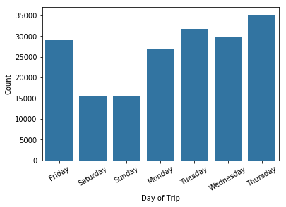

```python
sb.countplot(data=df, x='start_day_of_week', color=sb.color_palette()[0]);
plt.xticks(rotation=30)
plt.xlabel('Day of Trip');
plt.ylabel('Count');
```

The figure shows that Thursday the most day that users use the system, The least days have bike sharing is in weekends

```python
df['member_gender'].unique()
```

```
array(['Male', nan, 'Other', 'Female'], dtype=object)
```

```python
gender = ['Male','Female','Other']
gendercat = pd.api.types.CategoricalDtype(ordered=True, categories=gender)
df['member_gender'] = df['member_gender'].astype(gendercat)
```

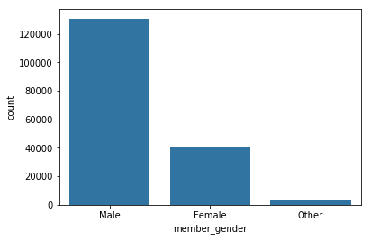

```python
sb.countplot(data=df, x='member_gender', color=sb.color_palette()[0],order= df['member_gender'].value_counts().index);
```

We can that the gender of most users is male

```python
df['user_type'].unique()
```

```
array(['Customer', 'Subscriber'], dtype=object)
```

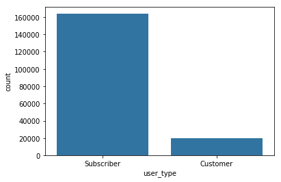

```python
sb.countplot(data=df, x=df['user_type'], color=sb.color_palette()[0],order= df['user_type'].value_counts().index);
```

the type of most users is subscriber because they have purpose use the bikes to ride in week work days, but the customers ride in weekends just to have fun

```python
df['duration_sec'].describe()
```

```
count    183412.000000
mean        726.078435
std        1794.389780
min          61.000000
25%         325.000000
50%         514.000000
75%         796.000000
max       85444.000000
Name: duration_sec, dtype: float64
```

```python
np.log10(df['duration_sec'].describe())
```

```
count    5.263428
mean     2.860984
std      3.253917
min      1.785330
25%      2.511883
50%      2.710963
75%      2.900913
max      4.931682
Name: duration_sec, dtype: float64
```

```
(0, 6000)
```

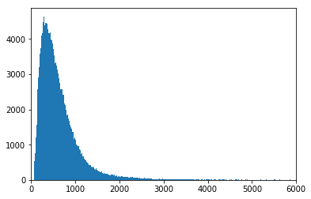

```python
plt.hist(data = df, x = df['duration_sec'], bins = 5000);
plt.xlim(0,6000)
```

we can find the this histogram in not normal distrubuted

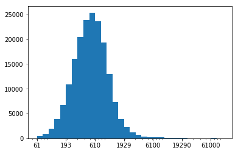

```python
bins = 10**np.arange(1.785330, 4.931682+0.1, 0.1)
plt.hist(data = df, x = 'duration_sec', bins = bins);
plt.xscale('log')
ticks = np.round(bins[::5] , 0).astype(int)
labels = ['{}'.format(v) for v in ticks]
plt.xticks(ticks, labels);
```

now we can find that the plot distrubuted normally so can see the outliers

```python
(2021-df['member_birth_year']).describe()
```

```
count    175147.000000
mean         36.193563
std          10.116689
min          20.000000
25%          29.000000
50%          34.000000
75%          41.000000
max         143.000000
Name: member_birth_year, dtype: float64
```

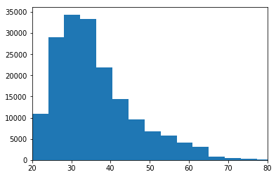

```python
bins = np.arange(20, 143+10, 10)
plt.hist(data = df, x = 2021-df['member_birth_year'],bins=30);
plt.xlim((20,80));
```

```python
df['start_hour'] = df['start_time'].dt.strftime('%H').astype(int)
```

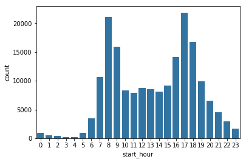

```python
sb.countplot(data=df, x='start_hour', color=sb.color_palette()[0]);
```

We can notice that the most hours users ride in day are 8 AM this time the workers go to work and 5 PM that come back to home.

> Make sure that, after every plot or related series of plots, that you include a Markdown cell with comments about what you observed, and what you plan on investigating next.

### Discuss the distribution(s) of your variable(s) of interest. Were there any unusual points? Did you need to perform any transformations?

> - We can notice that the most hours users ride in day are 8 AM this time the workers go to work and 5 PM that come back to home.
> - Thursday the most day that users use the system, The least days have bike sharing are in weekends
> - the gender of most users is male
> - the type of most users is subscriber because they have purpose use the bikes to ride in week work days, but the customers ride in weekends just to have fun

### Of the features you investigated, were there any unusual distributions? Did you perform any operations on the data to tidy, adjust, or change the form of the data? If so, why did you do this?

> Yes the duration was not distributed normally

## Bivariate Exploration

> In this section, investigate relationships between pairs of variables in your data. Make sure the variables that you cover here have been introduced in some fashion in the previous section (univariate exploration).

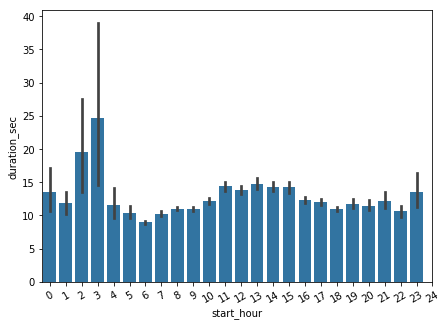

```python
plt.figure(figsize=[7,5])
bins = np.arange(0, 24+1, 1)
sb.barplot(data = df, x = 'start_hour', y = df['duration_sec']/60,color=sb.color_palette()[0]);
ticks = np.round(bins[::1] , 0).astype(int)
labels = ['{}'.format(v) for v in ticks]
plt.xticks(ticks, labels,rotation=30);
```

the most hours that users ride long trips is 2 : 3 AM, but we notice the uncertainty of the mean as the whiskers is too long

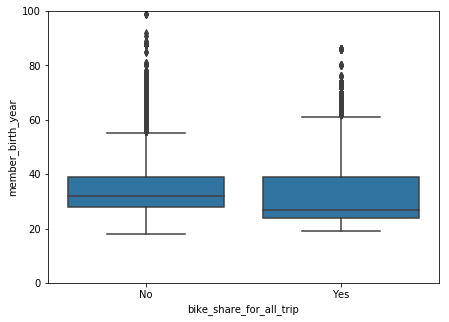

```python
plt.figure(figsize=[7,5])
#bins = np.arange(0, 24+1, 1)
sb.boxplot(data = df, x = 'bike_share_for_all_trip', y =2019- df['member_birth_year'],color=sb.color_palette()[0]);
#ticks = np.round(bins[::1] , 0).astype(int)
#labels = ['{}'.format(v) for v in ticks]
#plt.xticks(ticks, labels,rotation=30);
plt.ylim([0,100]);
```

```python
sub_df=df.sample(frac=0.03, random_state=1)
```

```python
sub_df.shape
```

[output not shown]

```python
(10**(sub_df['duration_sec']/60).apply(np.log10)).describe()
```

```
count    5502.000000
mean       11.269932
std        14.455754
min         1.083333
25%         5.333333
50%         8.500000
75%        13.295833
max       545.800000
Name: duration_sec, dtype: float64
```

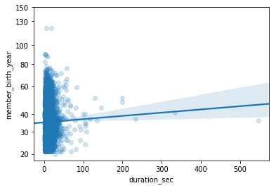

```python
sb.regplot(data = sub_df, y = (2021-sub_df['member_birth_year']).apply(lambda x:x**(1/3)), x = (sub_df['duration_sec']/60),scatter_kws={'alpha':1/5});
tick_locs = [20,30,40,60,80, 100,130,150]
plt.yticks(list(map(lambda x :pow(x,1/3),tick_locs)), tick_locs);
```

```python
((df['duration_sec']/60).apply(np.log10)).describe()
```

```
count    183412.000000
mean          0.934454
std           0.309396
min           0.007179
25%           0.733732
50%           0.932812
75%           1.122762
max           3.153530
Name: duration_sec, dtype: float64
```

```python
'''bins = 10**np.arange(2.513218, 4.274689+0.1, 0.1)
ticks = [326,1030, 3260,10309, 32600]
labels = ['{}'.format(v) for v in ticks]
plt.hist(diamonds["price"],bins = bins);
plt.xscale('log')
plt.xticks(ticks, labels);bins = 10**np.arange(2.513218, 4.274689+0.1, 0.1)
ticks = [326,1030, 3260,10309, 32600]
labels = ['{}'.format(v) for v in ticks]
plt.hist(diamonds["price"],bins = bins);
plt.xscale('log')
plt.xticks(ticks, labels);'''
```

```python
df.groupby(['member_birth_year'])['duration_sec'].mean().describe()
```

```
count      75.000000
mean      732.200594
std       285.123134
min       215.573034
25%       647.267954
50%       703.306927
75%       751.584970
max      2444.911765
Name: duration_sec, dtype: float64
```

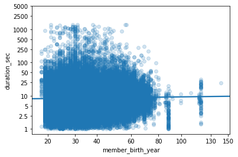

```python
sb.regplot(data = df, x = (2019-df['member_birth_year']).apply(lambda x:x**(1/3)),
                       y = (df['duration_sec']/60).apply(np.log10),scatter_kws={'alpha':1/5},fit_reg = False);

tick_locs = [1,2.5,5, 10,25,50,100,250,500,1000,2500,5000]
plt.yticks(np.log10(tick_locs), tick_locs);

tick_locs = [18,30,40,60,80, 100,130,150]
plt.xticks(list(map(lambda x :pow(x,1/3),tick_locs)), tick_locs);
```

the figure shows that members from 18 to the age of 60 ride frequently and and ride long time but the member bigger than that ride less and to short time

```python
df.head(3)
```

|  | duration_sec | start_time | end_time | start_station_id | start_station_name | start_station_latitude | start_station_longitude | end_station_id | end_station_name | end_station_latitude | end_station_longitude | bike_id | user_type | member_birth_year | member_gender | bike_share_for_all_trip | start_day_of_week | start_hour |
| --- | --- | --- | --- | --- | --- | --- | --- | --- | --- | --- | --- | --- | --- | --- | --- | --- | --- | --- |
| 0 | 52185 | 2019-02-28 17:32:10.145 | 2019-03-01 08:01:55.975 | 21.0 | Montgomery St BART Station (Market St at 2nd St) | 37.789625 | -122.400811 | 13.0 | Commercial St at Montgomery St | 37.794231 | -122.402923 | 4902 | Customer | 1984.0 | Male | No | Thursday | 17 |
| 1 | 42521 | 2019-02-28 18:53:21.789 | 2019-03-01 06:42:03.056 | 23.0 | The Embarcadero at Steuart St | 37.791464 | -122.391034 | 81.0 | Berry St at 4th St | 37.775880 | -122.393170 | 2535 | Customer | NaN | NaN | No | Thursday | 18 |
| 2 | 61854 | 2019-02-28 12:13:13.218 | 2019-03-01 05:24:08.146 | 86.0 | Market St at Dolores St | 37.769305 | -122.426826 | 3.0 | Powell St BART Station (Market St at 4th St) | 37.786375 | -122.404904 | 5905 | Customer | 1972.0 | Male | No | Thursday | 12 |

```python
(df['duration_sec']/60).describe()
```

```
count    183412.000000
mean         12.101307
std          29.906496
min           1.016667
25%           5.416667
50%           8.566667
75%          13.266667
max        1424.066667
Name: duration_sec, dtype: float64
```

```python
(df['duration_sec']).describe()
```

```
count    183412.000000
mean        726.078435
std        1794.389780
min          61.000000
25%         325.000000
50%         514.000000
75%         796.000000
max       85444.000000
Name: duration_sec, dtype: float64
```

```python
make_frequency = df['end_station_name'].value_counts()
idx = np.sum(make_frequency > 1000)
most_makes = make_frequency.index[:idx]
df_end_station_sub = df.loc[df['end_station_name'].isin(most_makes)]
make_means = df_end_station_sub.groupby('end_station_name').mean()
comb_order = make_means.sort_values('duration_sec', ascending = False).index
```

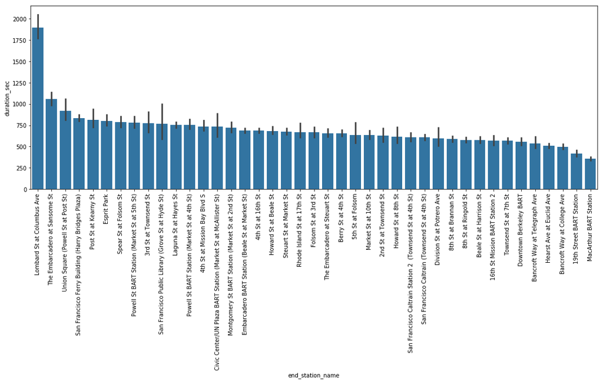

```python
plt.figure(figsize=[18,6])
sb.barplot(data = df_end_station_sub, x = 'end_station_name', y = 'duration_sec',
               color = sb.color_palette()[0], order = comb_order)
plt.xticks(rotation=90);
```

```python
df.groupby('end_station_name')['duration_sec'].mean().sort_values(ascending=False).head()
#outlier 26000
```

```
end_station_name
16th St Depot                 26000.166667
Willow St at Vine St           3535.600000
Farnam St at Fruitvale Ave     3415.450000
Fell St at Stanyan St          2139.596639
Lane St at Revere Ave          2035.239130
Name: duration_sec, dtype: float64
```

```python
make_frequency = df.groupby('end_station_name')['duration_sec'].mean().sort_values(ascending=False)
idx = np.sum(make_frequency > 1000)
most_makes = make_frequency.index[:idx]
fuel_econ_sub = df.loc[df['end_station_name'].isin(most_makes)]
make_means = fuel_econ_sub.groupby('end_station_name').mean()
comb_order = make_means.sort_values('duration_sec', ascending = False).index
```

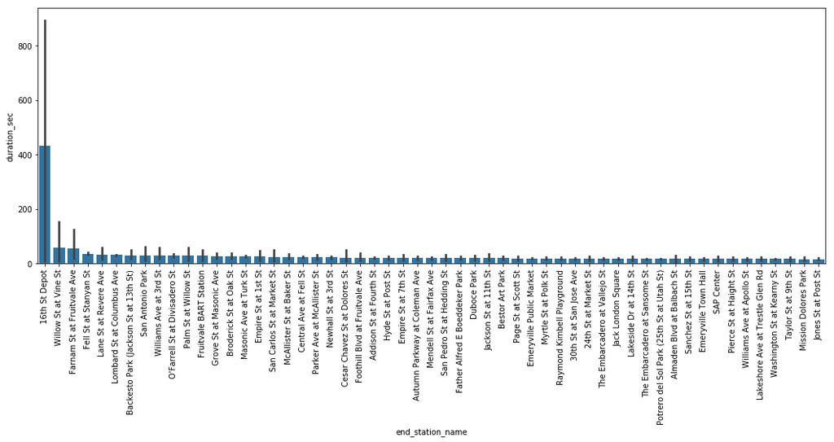

```python
plt.figure(figsize=[18,6])
sb.barplot(data = fuel_econ_sub, x = 'end_station_name', y = df['duration_sec']/60,
               color = sb.color_palette()[0], order = comb_order)
plt.xticks(rotation=90);
```

here we see the station that the member take the longest time to approach it as it's end station but it consist of outlier as the avarage duration of time to approach '16th St Depot' is more than 400 minutes while the other stations is less than 60

```python
make_frequency = df.groupby('end_station_name')['duration_sec'].mean().sort_values(ascending=False)
idx = np.sum(make_frequency > 1000)
most_makes = make_frequency.index[1:idx]
fuel_econ_sub = df.loc[df['end_station_name'].isin(most_makes)]
make_means = fuel_econ_sub.groupby('end_station_name').mean()
comb_order = make_means.sort_values('duration_sec', ascending = False).index
```

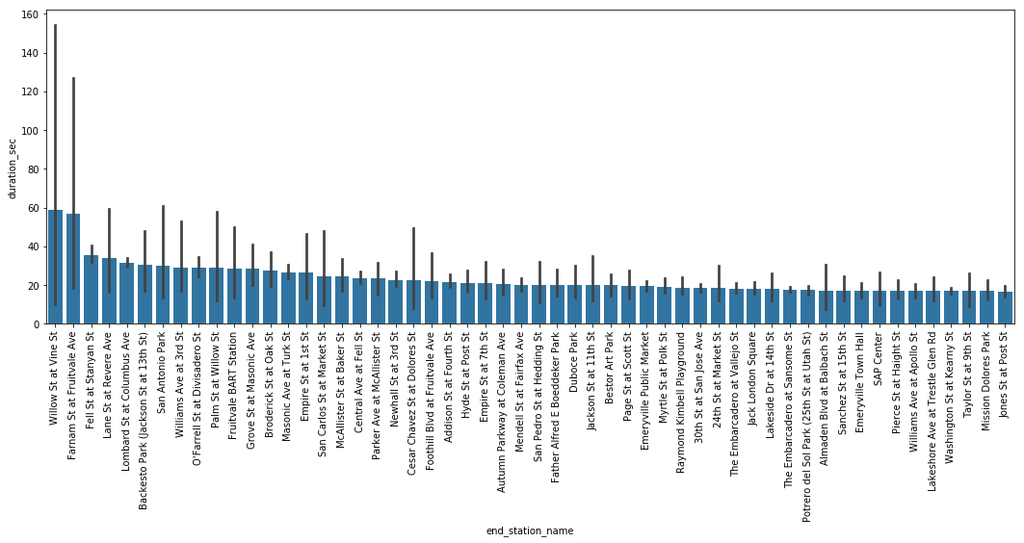

```python
plt.figure(figsize=[18,6])
sb.barplot(data = fuel_econ_sub, x = 'end_station_name', y = df['duration_sec']/60,
               color = sb.color_palette()[0], order = comb_order)
plt.xticks(rotation=90);
```

after we remove the outlier that make me distinguish between the stations that user take time to park in it

```python
df.columns
```

```
Index(['duration_sec', 'start_time', 'end_time', 'start_station_id',
       'start_station_name', 'start_station_latitude',
       'start_station_longitude', 'end_station_id', 'end_station_name',
       'end_station_latitude', 'end_station_longitude', 'bike_id', 'user_type',
       'member_birth_year', 'member_gender', 'bike_share_for_all_trip',
       'start_day_of_week', 'start_hour', 'age'],
      dtype='object')
```

```python
df['from_start_to_end']=df['start_station_id'].astype(str)+' to '+df['end_station_id'].astype(str)
```

```python
df['from_start_to_end'].head(3)
```

```
0    21.0 to 13.0
1    23.0 to 81.0
2     86.0 to 3.0
Name: from_start_to_end, dtype: object
```

```python
(df.groupby('from_start_to_end')['duration_sec'].mean().sort_values(ascending=False)/60).head(10)
```

```
from_start_to_end
77.0 to 344.0     1390.116667
39.0 to 52.0      1209.833333
5.0 to 344.0      1163.383333
7.0 to 47.0        950.983333
37.0 to 91.0       947.866667
46.0 to 46.0       932.766667
90.0 to 52.0       893.583333
25.0 to 109.0      846.750000
235.0 to 218.0     740.716667
41.0 to 73.0       572.641667
Name: duration_sec, dtype: float64
```

```python
df.groupby('from_start_to_end')['duration_sec'].mean().sort_values(ascending=False).describe()
```

```
count    23649.000000
mean       958.699919
std       1631.252182
min         73.000000
25%        507.500000
50%        763.285714
75%       1089.000000
max      83407.000000
Name: duration_sec, dtype: float64
```

```python
make_frequency = df.groupby('from_start_to_end')['duration_sec'].mean().sort_values(ascending=False)
idx = np.sum(make_frequency > 20000)
most_makes = make_frequency.index[:idx]
fuel_econ_sub = df.loc[df['from_start_to_end'].isin(most_makes)]
make_means = fuel_econ_sub.groupby('from_start_to_end').mean()
comb_order = make_means.sort_values('duration_sec', ascending = False).index
```

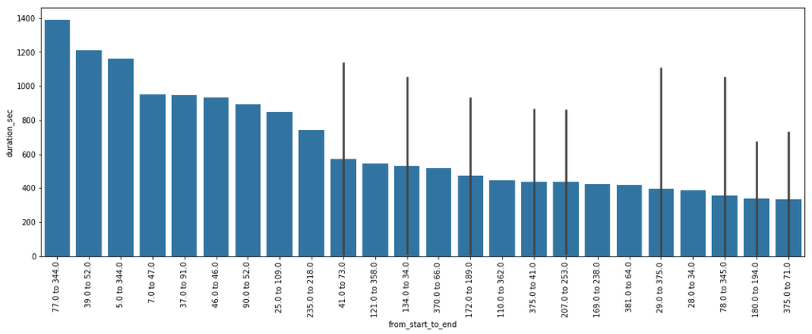

```python
plt.figure(figsize=[18,6])
sb.barplot(data = fuel_econ_sub, x = 'from_start_to_end', y = df['duration_sec']/60,
               color = sb.color_palette()[0], order = comb_order)
plt.xticks(rotation=90);
```

```python
the_largest=df[df['from_start_to_end']=='77.0 to 344.0']
ab= 'from '+ the_largest['start_station_name'].astype(str)+' to '+the_largest['end_station_name'].astype(str)+' toke '+(the_largest['duration_sec']/60).astype(int).astype(str)+' min.'
```

```python
ab.astype(str).values[0]
```

```
'from 11th St at Natoma St to 16th St Depot toke 1390 min.'
```

```python
most_makes2 = make_frequency.index[:1]
fuel_econ_sub2 = df.loc[df['from_start_to_end'].isin(most_makes2)]
ab2=('from '+ the_largest['start_station_name'].astype(str)
     +' to '+the_largest['end_station_name'].astype(str)+' toke '+(the_largest['duration_sec']/60).astype(int).astype(str)+' min.')
ab2.astype(str).values[0]
```

```python
ab2.astype(str).values[0]
```

```
'from 11th St at Natoma St to 16th St Depot toke 1390 min.'
```

```python
df_gender_sub = df.loc[df['member_gender'].isin(['Male', 'Female'])]
```

```python
ct_counts = df_gender_sub.groupby(['member_gender', 'user_type']).size().reset_index(name='count')
```

```python
ct_counts = ct_counts.pivot(index = 'member_gender', columns = 'user_type', values = 'count')
```

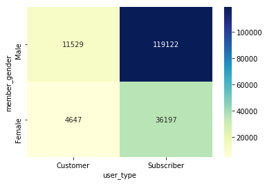

```python
sb.heatmap(ct_counts,annot = True, fmt = 'd',cmap="YlGnBu")
```

the most users is male and there type is subscriber

```python
df__sub=df.dropna(subset=['start_day_of_week','start_hour'])
```

```python
cat_means = df__sub.groupby(['start_day_of_week', 'start_hour']).size().reset_index(name='count')
cat_means = cat_means.pivot(index = 'start_day_of_week', columns = 'start_hour',
                            values = 'count')
```

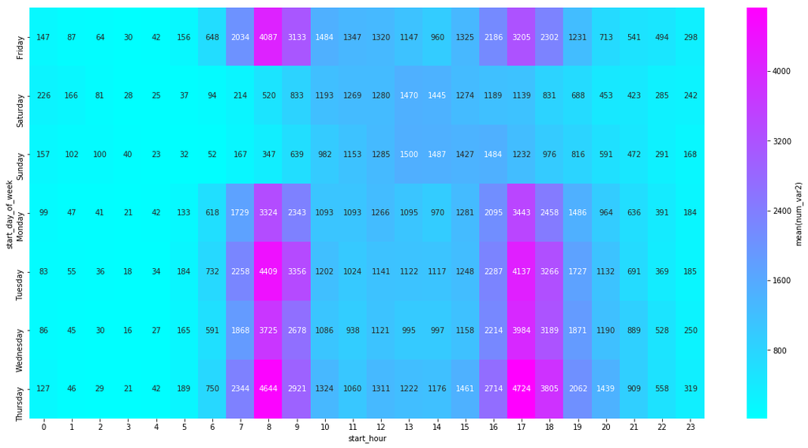

```python
plt.figure(figsize = [20, 10])
sb.heatmap(cat_means,cmap = 'cool', annot = True, fmt = 'd',cbar_kws = {'label' : 'mean(num_var2)'});
```

here the graph clarify the times that the user use the program by the day and the time so we notice that thursday 17 is the most time

### Talk about some of the relationships you observed in this part of the investigation. How did the feature(s) of interest vary with other features in the dataset?

- the most users is male and there type is subscriber
- members from 18 to the age of 60 ride frequently and and ride long time but the member bigger than that ride less and to short time
- the most hours that users ride long trips is 2 : 3 AM, but we notice the uncertainty of the mean as the whiskers is too long

### Did you observe any interesting relationships between the other features (not the main feature(s) of interest)?

> here we see the station that the member take the longest time to approach it as it's end station but it consist of outlier as the avarage duration of time to approach '16th St Depot' is more than 400 minutes while the other stations is less than 60 the most users is male and there type is subscriber

## Multivariate Exploration

> Create plots of three or more variables to investigate your data even further. Make sure that your investigations are justified, and follow from your work in the previous sections.

```python
ct_counts2 = df_gender_sub.groupby(['member_gender', 'user_type'])['duration_sec'].mean().reset_index(name='count')
```

```python
ct_counts2 = ct_counts2.pivot(index = 'member_gender', columns = 'user_type', values = 'count')
```

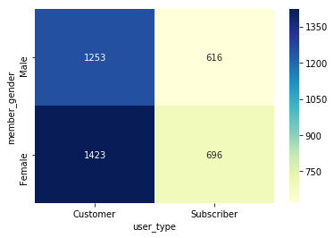

```python
sb.heatmap(ct_counts2,annot = True, fmt = '0.0f',cmap="YlGnBu");
```

the longest trips from females and their type is customer

```python
cat_means = df__sub.groupby(['start_day_of_week', 'start_hour'])['duration_sec'].mean().reset_index(name='count')
cat_means = cat_means.pivot(index = 'start_day_of_week', columns = 'start_hour',
                            values = 'count')/60
```

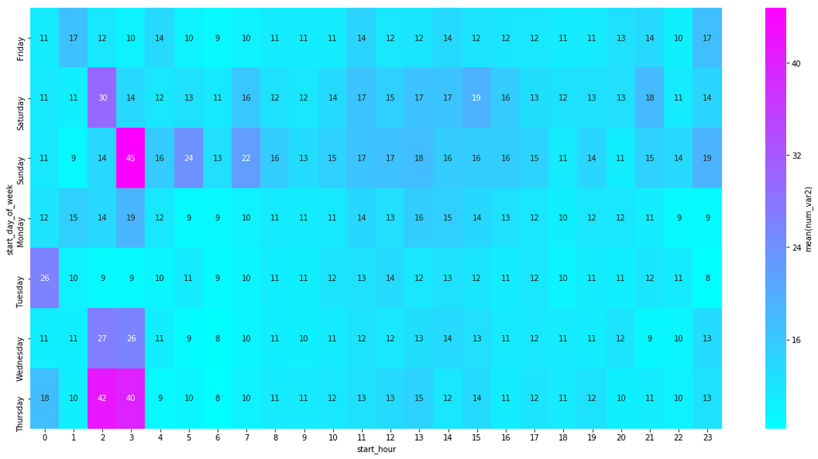

```python
plt.figure(figsize = [20, 10])
sb.heatmap(cat_means,cmap = 'cool', annot = True, fmt = '0.0f',cbar_kws = {'label' : 'mean(num_var2)'});
```

the longest trip at 3 AM in weekend (Sunday)

```python
ordered_var = pd.api.types.CategoricalDtype(ordered = True,
                                                    categories = ['Male','Female'])
df_gender_sub['member_gender'] = df_gender_sub['member_gender'].astype(ordered_var)
```

```
(0, 50)
```

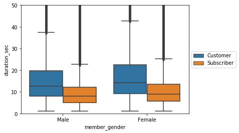

```python
sb.boxplot(data = df_gender_sub, x = 'member_gender', y = df_gender_sub['duration_sec']/60, hue = 'user_type')
plt.legend(loc = 6, bbox_to_anchor = (1.0, 0.5))
plt.ylim([0,50])
```

The customer take trips longer than subscriber

```
(0, 50)
```

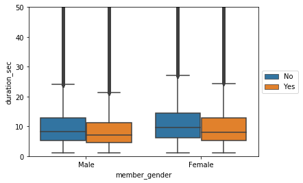

```python
sb.boxplot(data = df_gender_sub, x = 'member_gender', y = df_gender_sub['duration_sec']/60, hue = 'bike_share_for_all_trip')
plt.legend(loc = 6, bbox_to_anchor = (1.0, 0.5))
plt.ylim([0,50])
```

### Talk about some of the relationships you observed in this part of the investigation. Were there features that strengthened each other in terms of looking at your feature(s) of interest?

> the female users ride longer than the male users

> At the end of your report, make sure that you export the notebook as an html file from the `File > Download as... > HTML` menu. Make sure you keep track of where the exported file goes, so you can put it in the same folder as this notebook for project submission. Also, make sure you remove all of the quote-formatted guide notes like this one before you finish your report!